# Risk Factor Analysis

## Outcome Variable

**Outcome Variable:** whz

## Predictor Variables

**Intervention Variable:** mage

**Adjustment Set:**

- arm
- meducyrs
- feducyrs
- W_mhtcm
- single
- delta_meducyrs
- delta_feducyrs
- delta_W_mhtcm
- delta_single

## Stratifying Variables

The analysis was stratified on these variable(s):

- agecat
- studyid
- country

## Data Summary

| agecat | studyid | country | mage | n_cell | n |
| --- | --- | --- | --- | --- | --- |
| Birth | ki0047075b-MAL-ED | BANGLADESH | [20-30) | 164 | 241 |
| Birth | ki0047075b-MAL-ED | BANGLADESH | <20 | 34 | 241 |
| Birth | ki0047075b-MAL-ED | BANGLADESH | >=30 | 43 | 241 |
| Birth | ki0047075b-MAL-ED | BRAZIL | [20-30) | 110 | 183 |
| Birth | ki0047075b-MAL-ED | BRAZIL | <20 | 34 | 183 |
| Birth | ki0047075b-MAL-ED | BRAZIL | >=30 | 39 | 183 |
| Birth | ki0047075b-MAL-ED | INDIA | [20-30) | 163 | 202 |
| Birth | ki0047075b-MAL-ED | INDIA | <20 | 24 | 202 |
| Birth | ki0047075b-MAL-ED | INDIA | >=30 | 15 | 202 |
| Birth | ki0047075b-MAL-ED | NEPAL | [20-30) | 129 | 168 |
| Birth | ki0047075b-MAL-ED | NEPAL | <20 | 4 | 168 |
| Birth | ki0047075b-MAL-ED | NEPAL | >=30 | 35 | 168 |
| Birth | ki0047075b-MAL-ED | PERU | [20-30) | 142 | 279 |
| Birth | ki0047075b-MAL-ED | PERU | <20 | 73 | 279 |
| Birth | ki0047075b-MAL-ED | PERU | >=30 | 64 | 279 |
| Birth | ki0047075b-MAL-ED | SOUTH AFRICA | [20-30) | 132 | 258 |
| Birth | ki0047075b-MAL-ED | SOUTH AFRICA | <20 | 40 | 258 |
| Birth | ki0047075b-MAL-ED | SOUTH AFRICA | >=30 | 86 | 258 |
| Birth | ki0047075b-MAL-ED | TANZANIA, UNITED REPUBLIC OF | [20-30) | 70 | 118 |
| Birth | ki0047075b-MAL-ED | TANZANIA, UNITED REPUBLIC OF | <20 | 9 | 118 |
| Birth | ki0047075b-MAL-ED | TANZANIA, UNITED REPUBLIC OF | >=30 | 39 | 118 |
| Birth | ki1000108-CMC-V-BCS-2002 | INDIA | [20-30) | 76 | 88 |
| Birth | ki1000108-CMC-V-BCS-2002 | INDIA | <20 | 7 | 88 |
| Birth | ki1000108-CMC-V-BCS-2002 | INDIA | >=30 | 5 | 88 |
| Birth | ki1000108-IRC | INDIA | [20-30) | 289 | 343 |
| Birth | ki1000108-IRC | INDIA | <20 | 28 | 343 |
| Birth | ki1000108-IRC | INDIA | >=30 | 26 | 343 |
| Birth | ki1000109-EE | PAKISTAN | [20-30) | 0 | 1 |
| Birth | ki1000109-EE | PAKISTAN | <20 | 0 | 1 |
| Birth | ki1000109-EE | PAKISTAN | >=30 | 1 | 1 |

[output cut: 174 more lines]

The following strata were considered:

- agecat: 24 months, studyid: ki0047075b-MAL-ED, country: BANGLADESH
- agecat: 24 months, studyid: ki0047075b-MAL-ED, country: BRAZIL
- agecat: 24 months, studyid: ki0047075b-MAL-ED, country: INDIA
- agecat: 24 months, studyid: ki0047075b-MAL-ED, country: NEPAL
- agecat: 24 months, studyid: ki0047075b-MAL-ED, country: PERU
- agecat: 24 months, studyid: ki0047075b-MAL-ED, country: SOUTH AFRICA
- agecat: 24 months, studyid: ki0047075b-MAL-ED, country: TANZANIA, UNITED REPUBLIC OF
- agecat: 24 months, studyid: ki1000108-CMC-V-BCS-2002, country: INDIA
- agecat: 24 months, studyid: ki1000108-IRC, country: INDIA
- agecat: 24 months, studyid: ki1017093-NIH-Birth, country: BANGLADESH
- agecat: 24 months, studyid: ki1017093b-PROVIDE, country: BANGLADESH
- agecat: 24 months, studyid: ki1017093c-NIH-Crypto, country: BANGLADESH
- agecat: 24 months, studyid: ki1066203-TanzaniaChild2, country: TANZANIA, UNITED REPUBLIC OF
- agecat: 24 months, studyid: ki1101329-Keneba, country: GAMBIA
- agecat: 24 months, studyid: ki1113344-GMS-Nepal, country: NEPAL
- agecat: 24 months, studyid: ki1119695-PROBIT, country: BELARUS
- agecat: 24 months, studyid: ki1126311-ZVITAMBO, country: ZIMBABWE
- agecat: 24 months, studyid: ki1135781-COHORTS, country: GUATEMALA
- agecat: 24 months, studyid: ki1135781-COHORTS, country: INDIA
- agecat: 24 months, studyid: ki1135781-COHORTS, country: PHILIPPINES
- agecat: 24 months, studyid: ki1148112-LCNI-5, country: MALAWI
- agecat: 24 months, studyid: kiGH5241-JiVitA-3, country: BANGLADESH
- agecat: 6 months, studyid: ki0047075b-MAL-ED, country: BANGLADESH
- agecat: 6 months, studyid: ki0047075b-MAL-ED, country: BRAZIL
- agecat: 6 months, studyid: ki0047075b-MAL-ED, country: INDIA
- agecat: 6 months, studyid: ki0047075b-MAL-ED, country: NEPAL
- agecat: 6 months, studyid: ki0047075b-MAL-ED, country: PERU
- agecat: 6 months, studyid: ki0047075b-MAL-ED, country: SOUTH AFRICA
- agecat: 6 months, studyid: ki0047075b-MAL-ED, country: TANZANIA, UNITED REPUBLIC OF
- agecat: 6 months, studyid: ki1000108-CMC-V-BCS-2002, country: INDIA
- agecat: 6 months, studyid: ki1000108-IRC, country: INDIA
- agecat: 6 months, studyid: ki1000109-EE, country: PAKISTAN
- agecat: 6 months, studyid: ki1000304b-SAS-CompFeed, country: INDIA
- agecat: 6 months, studyid: ki1000304b-SAS-FoodSuppl, country: INDIA
- agecat: 6 months, studyid: ki1017093-NIH-Birth, country: BANGLADESH
- agecat: 6 months, studyid: ki1017093b-PROVIDE, country: BANGLADESH
- agecat: 6 months, studyid: ki1017093c-NIH-Crypto, country: BANGLADESH
- agecat: 6 months, studyid: ki1066203-TanzaniaChild2, country: TANZANIA, UNITED REPUBLIC OF
- agecat: 6 months, studyid: ki1101329-Keneba, country: GAMBIA
- agecat: 6 months, studyid: ki1112895-Guatemala BSC, country: GUATEMALA
- agecat: 6 months, studyid: ki1113344-GMS-Nepal, country: NEPAL
- agecat: 6 months, studyid: ki1119695-PROBIT, country: BELARUS
- agecat: 6 months, studyid: ki1126311-ZVITAMBO, country: ZIMBABWE
- agecat: 6 months, studyid: ki1135781-COHORTS, country: GUATEMALA
- agecat: 6 months, studyid: ki1135781-COHORTS, country: INDIA
- agecat: 6 months, studyid: ki1135781-COHORTS, country: PHILIPPINES
- agecat: 6 months, studyid: ki1148112-LCNI-5, country: MALAWI
- agecat: 6 months, studyid: kiGH5241-JiVitA-3, country: BANGLADESH
- agecat: Birth, studyid: ki0047075b-MAL-ED, country: BANGLADESH
- agecat: Birth, studyid: ki0047075b-MAL-ED, country: BRAZIL
- agecat: Birth, studyid: ki0047075b-MAL-ED, country: INDIA
- agecat: Birth, studyid: ki0047075b-MAL-ED, country: NEPAL
- agecat: Birth, studyid: ki0047075b-MAL-ED, country: PERU
- agecat: Birth, studyid: ki0047075b-MAL-ED, country: SOUTH AFRICA
- agecat: Birth, studyid: ki0047075b-MAL-ED, country: TANZANIA, UNITED REPUBLIC OF
- agecat: Birth, studyid: ki1000108-CMC-V-BCS-2002, country: INDIA
- agecat: Birth, studyid: ki1000108-IRC, country: INDIA
- agecat: Birth, studyid: ki1000109-EE, country: PAKISTAN
- agecat: Birth, studyid: ki1000304b-SAS-CompFeed, country: INDIA
- agecat: Birth, studyid: ki1017093-NIH-Birth, country: BANGLADESH
- agecat: Birth, studyid: ki1017093c-NIH-Crypto, country: BANGLADESH
- agecat: Birth, studyid: ki1101329-Keneba, country: GAMBIA
- agecat: Birth, studyid: ki1119695-PROBIT, country: BELARUS
- agecat: Birth, studyid: ki1126311-ZVITAMBO, country: ZIMBABWE
- agecat: Birth, studyid: ki1135781-COHORTS, country: GUATEMALA
- agecat: Birth, studyid: ki1135781-COHORTS, country: INDIA
- agecat: Birth, studyid: ki1135781-COHORTS, country: PHILIPPINES
- agecat: Birth, studyid: kiGH5241-JiVitA-3, country: BANGLADESH

### Dropped Strata

Some strata were dropped due to rare outcomes:

- agecat: Birth, studyid: ki0047075b-MAL-ED, country: NEPAL
- agecat: Birth, studyid: ki1000109-EE, country: PAKISTAN
- agecat: Birth, studyid: ki1017093c-NIH-Crypto, country: BANGLADESH
- agecat: 6 months, studyid: ki1000109-EE, country: PAKISTAN
- agecat: 24 months, studyid: ki0047075b-MAL-ED, country: NEPAL
- agecat: 24 months, studyid: ki1066203-TanzaniaChild2, country: TANZANIA, UNITED REPUBLIC OF

## Methods Detail

We’re interested in the causal parameters $E[Y_a]$ for all values of $a \in \mathcal{A}$. These parameters represent the mean outcome if, possibly contrary to fact, we intervened to set all units to have $A=a$. Under the randomization and positivity assumptions, these are identified by the statistical parameters $\psi_a=E_W[E_{Y|A,W}(Y|A=a,W)]$. In addition, we’re interested in the mean of $Y$, $E[Y]$ under no intervention (the observed mean). We will estimate these parameters by using SuperLearner to fit the relevant likelihood factors – $E_{Y|A,W}(Y|A=a,W)$ and $p(A=a|W)$, and then updating our likelihood fit using a joint TMLE.

For unadjusted analyses ($W=\{\}$), initial likelihoods were estimated using Lrnr_glm to estimate the simple $E(Y|A)$ and Lrnr_mean to estimate $p(A)$. For adjusted analyses, a small library containing Lrnr_glmnet, Lrnr_xgboost, and Lrnr_mean was used.

Having estimated these parameters, we will then use the delta method to estimate relative risks and attributable risks relative to a prespecified baseline level of $A$.

# Results Detail

## Results Plots

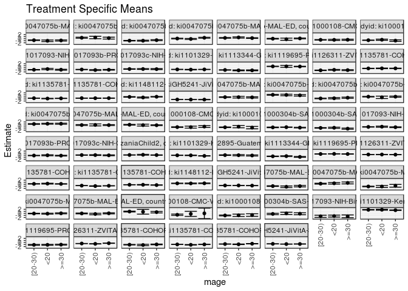

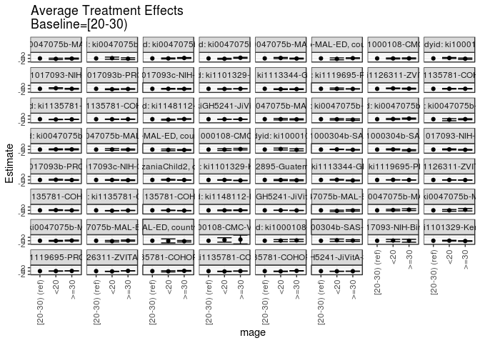

[figure not shown]

## Results Table

### Parameter: TSM

| agecat | studyid | country | intervention_level | baseline_level | estimate | ci_lower | ci_upper |
| --- | --- | --- | --- | --- | --- | --- | --- |
| Birth | ki0047075b-MAL-ED | BANGLADESH | [20-30) | NA | -0.9031763 | -1.0622897 | -0.7440629 |
| Birth | ki0047075b-MAL-ED | BANGLADESH | <20 | NA | -1.2378863 | -1.6418093 | -0.8339632 |
| Birth | ki0047075b-MAL-ED | BANGLADESH | >=30 | NA | -0.9368428 | -1.3010658 | -0.5726197 |
| Birth | ki0047075b-MAL-ED | BRAZIL | [20-30) | NA | 0.2908556 | 0.0722354 | 0.5094759 |
| Birth | ki0047075b-MAL-ED | BRAZIL | <20 | NA | 0.4705525 | 0.0979137 | 0.8431913 |
| Birth | ki0047075b-MAL-ED | BRAZIL | >=30 | NA | 0.6520848 | 0.1802020 | 1.1239676 |
| Birth | ki0047075b-MAL-ED | INDIA | [20-30) | NA | -1.0943534 | -1.2438676 | -0.9448391 |
| Birth | ki0047075b-MAL-ED | INDIA | <20 | NA | -1.1080281 | -1.5921350 | -0.6239213 |
| Birth | ki0047075b-MAL-ED | INDIA | >=30 | NA | -0.7436250 | -1.4200250 | -0.0672250 |
| Birth | ki0047075b-MAL-ED | PERU | [20-30) | NA | -0.0776612 | -0.2220004 | 0.0666780 |
| Birth | ki0047075b-MAL-ED | PERU | <20 | NA | -0.1496897 | -0.3832731 | 0.0838936 |
| Birth | ki0047075b-MAL-ED | PERU | >=30 | NA | 0.0180156 | -0.2298660 | 0.2658971 |
| Birth | ki0047075b-MAL-ED | SOUTH AFRICA | [20-30) | NA | -0.0371629 | -0.2410963 | 0.1667705 |
| Birth | ki0047075b-MAL-ED | SOUTH AFRICA | <20 | NA | -0.3065061 | -0.6823103 | 0.0692981 |
| Birth | ki0047075b-MAL-ED | SOUTH AFRICA | >=30 | NA | 0.0261187 | -0.2323612 | 0.2845986 |
| Birth | ki0047075b-MAL-ED | TANZANIA, UNITED REPUBLIC OF | [20-30) | NA | 0.9022857 | 0.7039042 | 1.1006673 |
| Birth | ki0047075b-MAL-ED | TANZANIA, UNITED REPUBLIC OF | <20 | NA | 0.7844444 | -0.3846224 | 1.9535113 |
| Birth | ki0047075b-MAL-ED | TANZANIA, UNITED REPUBLIC OF | >=30 | NA | 0.5994872 | 0.2123816 | 0.9865928 |
| Birth | ki1000108-CMC-V-BCS-2002 | INDIA | [20-30) | NA | -0.7036842 | -1.0454584 | -0.3619100 |
| Birth | ki1000108-CMC-V-BCS-2002 | INDIA | <20 | NA | -0.2514286 | -1.5184159 | 1.0155587 |
| Birth | ki1000108-CMC-V-BCS-2002 | INDIA | >=30 | NA | 0.0040000 | -2.5765694 | 2.5845694 |
| Birth | ki1000108-IRC | INDIA | [20-30) | NA | -1.0314533 | -1.2379730 | -0.8249335 |
| Birth | ki1000108-IRC | INDIA | <20 | NA | -0.9657143 | -1.5437779 | -0.3876507 |
| Birth | ki1000108-IRC | INDIA | >=30 | NA | -0.8269231 | -1.4629238 | -0.1909223 |
| Birth | ki1000304b-SAS-CompFeed | INDIA | [20-30) | NA | -0.2709259 | -0.6001157 | 0.0582639 |
| Birth | ki1000304b-SAS-CompFeed | INDIA | <20 | NA | 0.0064720 | -0.5261620 | 0.5391060 |
| Birth | ki1000304b-SAS-CompFeed | INDIA | >=30 | NA | -0.1757251 | -0.6662535 | 0.3148034 |
| Birth | ki1017093-NIH-Birth | BANGLADESH | [20-30) | NA | -1.4406667 | -1.9632411 | -0.9180922 |
| Birth | ki1017093-NIH-Birth | BANGLADESH | <20 | NA | -1.3416667 | -1.8258691 | -0.8574642 |
| Birth | ki1017093-NIH-Birth | BANGLADESH | >=30 | NA | -1.4585714 | -2.1459417 | -0.7712011 |

[output cut: 156 more lines]

### Parameter: E(Y)

| agecat | studyid | country | intervention_level | baseline_level | estimate | ci_lower | ci_upper |
| --- | --- | --- | --- | --- | --- | --- | --- |
| Birth | ki0047075b-MAL-ED | BANGLADESH | NA | NA | -0.9630705 | -1.0989132 | -0.8272278 |
| Birth | ki0047075b-MAL-ED | BRAZIL | NA | NA | 0.4038798 | 0.2296279 | 0.5781316 |
| Birth | ki0047075b-MAL-ED | INDIA | NA | NA | -1.0682673 | -1.2076956 | -0.9288391 |
| Birth | ki0047075b-MAL-ED | PERU | NA | NA | -0.0735842 | -0.1836203 | 0.0364518 |
| Birth | ki0047075b-MAL-ED | SOUTH AFRICA | NA | NA | -0.0562791 | -0.2000837 | 0.0875255 |
| Birth | ki0047075b-MAL-ED | TANZANIA, UNITED REPUBLIC OF | NA | NA | 0.7932203 | 0.5962220 | 0.9902187 |
| Birth | ki1000108-CMC-V-BCS-2002 | INDIA | NA | NA | -0.6275000 | -0.9746292 | -0.2803708 |
| Birth | ki1000108-IRC | INDIA | NA | NA | -1.0105831 | -1.1973019 | -0.8238643 |
| Birth | ki1000304b-SAS-CompFeed | INDIA | NA | NA | -0.2697590 | -0.5399211 | 0.0004030 |
| Birth | ki1017093-NIH-Birth | BANGLADESH | NA | NA | -1.4239286 | -1.7688028 | -1.0790544 |
| Birth | ki1101329-Keneba | GAMBIA | NA | NA | 1.7036191 | 1.6208471 | 1.7863911 |
| Birth | ki1119695-PROBIT | BELARUS | NA | NA | -1.1463469 | -1.3562674 | -0.9364264 |
| Birth | ki1126311-ZVITAMBO | ZIMBABWE | NA | NA | -0.5140815 | -0.5399633 | -0.4881998 |
| Birth | ki1135781-COHORTS | GUATEMALA | NA | NA | -1.0621429 | -1.1631387 | -0.9611471 |
| Birth | ki1135781-COHORTS | INDIA | NA | NA | -0.9742815 | -1.0093427 | -0.9392203 |
| Birth | ki1135781-COHORTS | PHILIPPINES | NA | NA | -0.7427251 | -0.7890855 | -0.6963647 |
| Birth | kiGH5241-JiVitA-3 | BANGLADESH | NA | NA | -0.7239791 | -0.7438253 | -0.7041329 |
| 6 months | ki0047075b-MAL-ED | BANGLADESH | NA | NA | -0.1397960 | -0.2688682 | -0.0107238 |
| 6 months | ki0047075b-MAL-ED | BRAZIL | NA | NA | 0.9717225 | 0.8073791 | 1.1360658 |
| 6 months | ki0047075b-MAL-ED | INDIA | NA | NA | -0.7031481 | -0.8287310 | -0.5775653 |
| 6 months | ki0047075b-MAL-ED | NEPAL | NA | NA | 0.1110452 | -0.0202712 | 0.2423616 |
| 6 months | ki0047075b-MAL-ED | PERU | NA | NA | 1.0543956 | 0.9326967 | 1.1760945 |
| 6 months | ki0047075b-MAL-ED | SOUTH AFRICA | NA | NA | 0.5420735 | 0.3899459 | 0.6942011 |
| 6 months | ki0047075b-MAL-ED | TANZANIA, UNITED REPUBLIC OF | NA | NA | 0.5170513 | 0.3872178 | 0.6468847 |
| 6 months | ki1000108-CMC-V-BCS-2002 | INDIA | NA | NA | -0.5026766 | -0.6536848 | -0.3516685 |
| 6 months | ki1000108-IRC | INDIA | NA | NA | -0.5989297 | -0.7344491 | -0.4634104 |
| 6 months | ki1000304b-SAS-CompFeed | INDIA | NA | NA | -0.6657084 | -0.8024377 | -0.5289791 |
| 6 months | ki1000304b-SAS-FoodSuppl | INDIA | NA | NA | -1.0121579 | -1.1280429 | -0.8962729 |
| 6 months | ki1017093-NIH-Birth | BANGLADESH | NA | NA | -0.4410128 | -0.5302967 | -0.3517289 |
| 6 months | ki1017093b-PROVIDE | BANGLADESH | NA | NA | -0.2083706 | -0.2927992 | -0.1239419 |
| 6 months | ki1017093c-NIH-Crypto | BANGLADESH | NA | NA | 0.0297622 | -0.0491685 | 0.1086930 |
| 6 months | ki1066203-TanzaniaChild2 | TANZANIA, UNITED REPUBLIC OF | NA | NA | 0.0782666 | 0.0252568 | 0.1312764 |
| 6 months | ki1101329-Keneba | GAMBIA | NA | NA | -0.1833795 | -0.2343793 | -0.1323798 |
| 6 months | ki1112895-Guatemala BSC | GUATEMALA | NA | NA | -0.0619988 | -0.1773839 | 0.0533863 |
| 6 months | ki1113344-GMS-Nepal | NEPAL | NA | NA | -0.6047987 | -0.6909649 | -0.5186325 |
| 6 months | ki1119695-PROBIT | BELARUS | NA | NA | 0.5789633 | 0.5190130 | 0.6389137 |
| 6 months | ki1126311-ZVITAMBO | ZIMBABWE | NA | NA | 0.3044096 | 0.2782992 | 0.3305201 |
| 6 months | ki1135781-COHORTS | GUATEMALA | NA | NA | 0.1940810 | 0.1226351 | 0.2655269 |
| 6 months | ki1135781-COHORTS | INDIA | NA | NA | -0.7119298 | -0.7444861 | -0.6793734 |
| 6 months | ki1135781-COHORTS | PHILIPPINES | NA | NA | -0.2938433 | -0.3352064 | -0.2524802 |
| 6 months | ki1148112-LCNI-5 | MALAWI | NA | NA | 0.4410463 | 0.3615008 | 0.5205919 |
| 6 months | kiGH5241-JiVitA-3 | BANGLADESH | NA | NA | -0.5933575 | -0.6128938 | -0.5738211 |
| 24 months | ki0047075b-MAL-ED | BANGLADESH | NA | NA | -0.8208255 | -0.9429246 | -0.6987264 |
| 24 months | ki0047075b-MAL-ED | BRAZIL | NA | NA | 0.4466272 | 0.2416144 | 0.6516401 |
| 24 months | ki0047075b-MAL-ED | INDIA | NA | NA | -0.9571111 | -1.0731621 | -0.8410602 |
| 24 months | ki0047075b-MAL-ED | PERU | NA | NA | 0.1199005 | -0.0000331 | 0.2398341 |
| 24 months | ki0047075b-MAL-ED | SOUTH AFRICA | NA | NA | 0.4267017 | 0.3074751 | 0.5459283 |
| 24 months | ki0047075b-MAL-ED | TANZANIA, UNITED REPUBLIC OF | NA | NA | 0.0500935 | -0.0748234 | 0.1750103 |
| 24 months | ki1000108-CMC-V-BCS-2002 | INDIA | NA | NA | -0.5571505 | -0.6585247 | -0.4557763 |
| 24 months | ki1000108-IRC | INDIA | NA | NA | -0.7458150 | -0.8368180 | -0.6548120 |
| 24 months | ki1017093-NIH-Birth | BANGLADESH | NA | NA | -0.9097790 | -1.0080462 | -0.8115117 |
| 24 months | ki1017093b-PROVIDE | BANGLADESH | NA | NA | -0.8879412 | -0.9708680 | -0.8050144 |
| 24 months | ki1017093c-NIH-Crypto | BANGLADESH | NA | NA | -0.6103502 | -0.7050157 | -0.5156847 |
| 24 months | ki1101329-Keneba | GAMBIA | NA | NA | -0.8079199 | -0.8550714 | -0.7607684 |
| 24 months | ki1113344-GMS-Nepal | NEPAL | NA | NA | -1.1315863 | -1.2192240 | -1.0439487 |
| 24 months | ki1119695-PROBIT | BELARUS | NA | NA | 0.6863435 | 0.5745700 | 0.7981170 |
| 24 months | ki1126311-ZVITAMBO | ZIMBABWE | NA | NA | -1.1830569 | -1.2831570 | -1.0829568 |
| 24 months | ki1135781-COHORTS | GUATEMALA | NA | NA | -0.2813755 | -0.3354674 | -0.2272835 |
| 24 months | ki1135781-COHORTS | INDIA | NA | NA | -0.6627749 | -0.6962103 | -0.6293395 |
| 24 months | ki1135781-COHORTS | PHILIPPINES | NA | NA | -0.6099592 | -0.6467541 | -0.5731643 |
| 24 months | ki1148112-LCNI-5 | MALAWI | NA | NA | -0.0116486 | -0.1020399 | 0.0787427 |
| 24 months | kiGH5241-JiVitA-3 | BANGLADESH | NA | NA | -1.2977181 | -1.3209986 | -1.2744376 |

### Parameter: ATE

| agecat | studyid | country | intervention_level | baseline_level | estimate | ci_lower | ci_upper |
| --- | --- | --- | --- | --- | --- | --- | --- |
| Birth | ki0047075b-MAL-ED | BANGLADESH | [20-30) | [20-30) | 0.0000000 | 0.0000000 | 0.0000000 |
| Birth | ki0047075b-MAL-ED | BANGLADESH | <20 | [20-30) | -0.3347100 | -0.7698147 | 0.1003948 |
| Birth | ki0047075b-MAL-ED | BANGLADESH | >=30 | [20-30) | -0.0336665 | -0.4323686 | 0.3650357 |
| Birth | ki0047075b-MAL-ED | BRAZIL | [20-30) | [20-30) | 0.0000000 | 0.0000000 | 0.0000000 |
| Birth | ki0047075b-MAL-ED | BRAZIL | <20 | [20-30) | 0.1796969 | -0.2529638 | 0.6123575 |
| Birth | ki0047075b-MAL-ED | BRAZIL | >=30 | [20-30) | 0.3612292 | -0.1613445 | 0.8838029 |
| Birth | ki0047075b-MAL-ED | INDIA | [20-30) | [20-30) | 0.0000000 | 0.0000000 | 0.0000000 |
| Birth | ki0047075b-MAL-ED | INDIA | <20 | [20-30) | -0.0136748 | -0.5208834 | 0.4935338 |
| Birth | ki0047075b-MAL-ED | INDIA | >=30 | [20-30) | 0.3507283 | -0.3425709 | 1.0440275 |
| Birth | ki0047075b-MAL-ED | PERU | [20-30) | [20-30) | 0.0000000 | 0.0000000 | 0.0000000 |
| Birth | ki0047075b-MAL-ED | PERU | <20 | [20-30) | -0.0720285 | -0.3460343 | 0.2019773 |
| Birth | ki0047075b-MAL-ED | PERU | >=30 | [20-30) | 0.0956768 | -0.1920243 | 0.3833778 |
| Birth | ki0047075b-MAL-ED | SOUTH AFRICA | [20-30) | [20-30) | 0.0000000 | 0.0000000 | 0.0000000 |
| Birth | ki0047075b-MAL-ED | SOUTH AFRICA | <20 | [20-30) | -0.2693433 | -0.6997462 | 0.1610597 |
| Birth | ki0047075b-MAL-ED | SOUTH AFRICA | >=30 | [20-30) | 0.0632815 | -0.2676777 | 0.3942408 |
| Birth | ki0047075b-MAL-ED | TANZANIA, UNITED REPUBLIC OF | [20-30) | [20-30) | 0.0000000 | 0.0000000 | 0.0000000 |
| Birth | ki0047075b-MAL-ED | TANZANIA, UNITED REPUBLIC OF | <20 | [20-30) | -0.1178413 | -1.3036206 | 1.0679380 |
| Birth | ki0047075b-MAL-ED | TANZANIA, UNITED REPUBLIC OF | >=30 | [20-30) | -0.3027985 | -0.7377767 | 0.1321796 |
| Birth | ki1000108-CMC-V-BCS-2002 | INDIA | [20-30) | [20-30) | 0.0000000 | 0.0000000 | 0.0000000 |
| Birth | ki1000108-CMC-V-BCS-2002 | INDIA | <20 | [20-30) | 0.4522556 | -0.8600197 | 1.7645309 |
| Birth | ki1000108-CMC-V-BCS-2002 | INDIA | >=30 | [20-30) | 0.7076842 | -1.8954193 | 3.3107878 |
| Birth | ki1000108-IRC | INDIA | [20-30) | [20-30) | 0.0000000 | 0.0000000 | 0.0000000 |
| Birth | ki1000108-IRC | INDIA | <20 | [20-30) | 0.0657390 | -0.5481078 | 0.6795858 |
| Birth | ki1000108-IRC | INDIA | >=30 | [20-30) | 0.2045302 | -0.4641606 | 0.8732210 |
| Birth | ki1000304b-SAS-CompFeed | INDIA | [20-30) | [20-30) | 0.0000000 | 0.0000000 | 0.0000000 |
| Birth | ki1000304b-SAS-CompFeed | INDIA | <20 | [20-30) | 0.2773979 | -0.4337424 | 0.9885382 |
| Birth | ki1000304b-SAS-CompFeed | INDIA | >=30 | [20-30) | 0.0952008 | -0.3693985 | 0.5598001 |
| Birth | ki1017093-NIH-Birth | BANGLADESH | [20-30) | [20-30) | 0.0000000 | 0.0000000 | 0.0000000 |
| Birth | ki1017093-NIH-Birth | BANGLADESH | <20 | [20-30) | 0.0990000 | -0.6134157 | 0.8114157 |
| Birth | ki1017093-NIH-Birth | BANGLADESH | >=30 | [20-30) | -0.0179048 | -0.8813641 | 0.8455546 |

[output cut: 156 more lines]

### Parameter: PAR

| agecat | studyid | country | intervention_level | baseline_level | estimate | ci_lower | ci_upper |
| --- | --- | --- | --- | --- | --- | --- | --- |
| Birth | ki0047075b-MAL-ED | BANGLADESH | [20-30) | NA | -0.0598942 | -0.1602017 | 0.0404132 |
| Birth | ki0047075b-MAL-ED | BRAZIL | [20-30) | NA | 0.1130242 | -0.0361346 | 0.2621829 |
| Birth | ki0047075b-MAL-ED | INDIA | [20-30) | NA | 0.0260860 | -0.0521716 | 0.1043437 |
| Birth | ki0047075b-MAL-ED | PERU | [20-30) | NA | 0.0040770 | -0.1053288 | 0.1134827 |
| Birth | ki0047075b-MAL-ED | SOUTH AFRICA | [20-30) | NA | -0.0191162 | -0.1664062 | 0.1281738 |
| Birth | ki0047075b-MAL-ED | TANZANIA, UNITED REPUBLIC OF | [20-30) | NA | -0.1090654 | -0.2864659 | 0.0683351 |
| Birth | ki1000108-CMC-V-BCS-2002 | INDIA | [20-30) | NA | 0.0761842 | -0.1123529 | 0.2647213 |
| Birth | ki1000108-IRC | INDIA | [20-30) | NA | 0.0208702 | -0.0542483 | 0.0959887 |
| Birth | ki1000304b-SAS-CompFeed | INDIA | [20-30) | NA | 0.0011669 | -0.1214636 | 0.1237973 |
| Birth | ki1017093-NIH-Birth | BANGLADESH | [20-30) | NA | 0.0167381 | -0.2985906 | 0.3320668 |
| Birth | ki1101329-Keneba | GAMBIA | [20-30) | NA | -0.0546188 | -0.1471999 | 0.0379623 |
| Birth | ki1119695-PROBIT | BELARUS | [20-30) | NA | 0.0182983 | 0.0004270 | 0.0361696 |
| Birth | ki1126311-ZVITAMBO | ZIMBABWE | [20-30) | NA | -0.0044102 | -0.0224677 | 0.0136474 |
| Birth | ki1135781-COHORTS | GUATEMALA | [20-30) | NA | 0.0335478 | -0.0744453 | 0.1415409 |
| Birth | ki1135781-COHORTS | INDIA | [20-30) | NA | -0.0113951 | -0.0365680 | 0.0137778 |
| Birth | ki1135781-COHORTS | PHILIPPINES | [20-30) | NA | 0.0215395 | -0.0165430 | 0.0596220 |
| Birth | kiGH5241-JiVitA-3 | BANGLADESH | [20-30) | NA | -0.0461571 | -0.0628459 | -0.0294682 |
| 6 months | ki0047075b-MAL-ED | BANGLADESH | [20-30) | NA | -0.0300972 | -0.1205225 | 0.0603280 |
| 6 months | ki0047075b-MAL-ED | BRAZIL | [20-30) | NA | -0.0669992 | -0.2030321 | 0.0690338 |
| 6 months | ki0047075b-MAL-ED | INDIA | [20-30) | NA | 0.0564398 | -0.0078725 | 0.1207520 |
| 6 months | ki0047075b-MAL-ED | NEPAL | [20-30) | NA | -0.0064323 | -0.0723020 | 0.0594375 |
| 6 months | ki0047075b-MAL-ED | PERU | [20-30) | NA | 0.0559907 | -0.0698726 | 0.1818539 |
| 6 months | ki0047075b-MAL-ED | SOUTH AFRICA | [20-30) | NA | 0.0567499 | -0.1066434 | 0.2201433 |
| 6 months | ki0047075b-MAL-ED | TANZANIA, UNITED REPUBLIC OF | [20-30) | NA | -0.1232256 | -0.2523024 | 0.0058511 |
| 6 months | ki1000108-CMC-V-BCS-2002 | INDIA | [20-30) | NA | 0.0276202 | -0.0496471 | 0.1048875 |
| 6 months | ki1000108-IRC | INDIA | [20-30) | NA | 0.0163578 | -0.0532078 | 0.0859233 |
| 6 months | ki1000304b-SAS-CompFeed | INDIA | [20-30) | NA | -0.0017266 | -0.0324811 | 0.0290279 |
| 6 months | ki1000304b-SAS-FoodSuppl | INDIA | [20-30) | NA | -0.0866687 | -0.1689751 | -0.0043623 |
| 6 months | ki1017093-NIH-Birth | BANGLADESH | [20-30) | NA | -0.0108338 | -0.0742085 | 0.0525409 |
| 6 months | ki1017093b-PROVIDE | BANGLADESH | [20-30) | NA | -0.0185085 | -0.0714372 | 0.0344202 |
| 6 months | ki1017093c-NIH-Crypto | BANGLADESH | [20-30) | NA | -0.0174118 | -0.0767100 | 0.0418863 |
| 6 months | ki1066203-TanzaniaChild2 | TANZANIA, UNITED REPUBLIC OF | [20-30) | NA | -0.0064331 | -0.0455567 | 0.0326905 |
| 6 months | ki1101329-Keneba | GAMBIA | [20-30) | NA | -0.0983739 | -0.1530174 | -0.0437304 |
| 6 months | ki1112895-Guatemala BSC | GUATEMALA | [20-30) | NA | -0.0760741 | -0.1701507 | 0.0180025 |
| 6 months | ki1113344-GMS-Nepal | NEPAL | [20-30) | NA | -0.0298396 | -0.0906422 | 0.0309630 |
| 6 months | ki1119695-PROBIT | BELARUS | [20-30) | NA | 0.0039579 | -0.0069657 | 0.0148815 |
| 6 months | ki1126311-ZVITAMBO | ZIMBABWE | [20-30) | NA | -0.0142452 | -0.0329748 | 0.0044843 |
| 6 months | ki1135781-COHORTS | GUATEMALA | [20-30) | NA | 0.0008463 | -0.0776559 | 0.0793484 |
| 6 months | ki1135781-COHORTS | INDIA | [20-30) | NA | -0.0369669 | -0.0595549 | -0.0143789 |
| 6 months | ki1135781-COHORTS | PHILIPPINES | [20-30) | NA | -0.0544473 | -0.0895459 | -0.0193487 |
| 6 months | ki1148112-LCNI-5 | MALAWI | [20-30) | NA | 0.0113796 | -0.0633820 | 0.0861411 |
| 6 months | kiGH5241-JiVitA-3 | BANGLADESH | [20-30) | NA | -0.0014790 | -0.0201594 | 0.0172015 |
| 24 months | ki0047075b-MAL-ED | BANGLADESH | [20-30) | NA | -0.0663462 | -0.1501178 | 0.0174255 |
| 24 months | ki0047075b-MAL-ED | BRAZIL | [20-30) | NA | -0.0142191 | -0.1865160 | 0.1580778 |
| 24 months | ki0047075b-MAL-ED | INDIA | [20-30) | NA | 0.0189785 | -0.0352728 | 0.0732298 |
| 24 months | ki0047075b-MAL-ED | PERU | [20-30) | NA | 0.0449730 | -0.0800034 | 0.1699494 |
| 24 months | ki0047075b-MAL-ED | SOUTH AFRICA | [20-30) | NA | 0.0347156 | -0.1132262 | 0.1826574 |
| 24 months | ki0047075b-MAL-ED | TANZANIA, UNITED REPUBLIC OF | [20-30) | NA | 0.0442970 | -0.0737571 | 0.1623511 |
| 24 months | ki1000108-CMC-V-BCS-2002 | INDIA | [20-30) | NA | 0.0017628 | -0.0449995 | 0.0485250 |
| 24 months | ki1000108-IRC | INDIA | [20-30) | NA | 0.0069158 | -0.0351308 | 0.0489624 |
| 24 months | ki1017093-NIH-Birth | BANGLADESH | [20-30) | NA | 0.0355265 | -0.0366284 | 0.1076814 |
| 24 months | ki1017093b-PROVIDE | BANGLADESH | [20-30) | NA | -0.0397376 | -0.0927793 | 0.0133041 |
| 24 months | ki1017093c-NIH-Crypto | BANGLADESH | [20-30) | NA | -0.0159236 | -0.0844992 | 0.0526520 |
| 24 months | ki1101329-Keneba | GAMBIA | [20-30) | NA | -0.0136485 | -0.0659082 | 0.0386112 |
| 24 months | ki1113344-GMS-Nepal | NEPAL | [20-30) | NA | -0.0696273 | -0.1345116 | -0.0047429 |
| 24 months | ki1119695-PROBIT | BELARUS | [20-30) | NA | -0.0118780 | -0.0614595 | 0.0377034 |
| 24 months | ki1126311-ZVITAMBO | ZIMBABWE | [20-30) | NA | 0.0609768 | -0.0134665 | 0.1354202 |
| 24 months | ki1135781-COHORTS | GUATEMALA | [20-30) | NA | 0.0219794 | -0.0352651 | 0.0792238 |
| 24 months | ki1135781-COHORTS | INDIA | [20-30) | NA | -0.0330265 | -0.0564641 | -0.0095890 |
| 24 months | ki1135781-COHORTS | PHILIPPINES | [20-30) | NA | -0.0129492 | -0.0433726 | 0.0174741 |
| 24 months | ki1148112-LCNI-5 | MALAWI | [20-30) | NA | -0.0198414 | -0.1074405 | 0.0677577 |
| 24 months | kiGH5241-JiVitA-3 | BANGLADESH | [20-30) | NA | -0.0101177 | -0.0336289 | 0.0133936 |